# Divorced From Feelings

*Team Technical Difficulties:* Lily Dao, Reuben Lewis, Maya Sivanandan, Kate McCurley, and Izzie Abilheira

### Research Question

What are common feelings that may create friction in the interaction between the client and the attorney for a divorce-related case?

### Context

Our group was provided data from the American Bar Association with information about attorneys, clients, and the interactions between them. We were particularly interested in the interactions between the attorneys and the clients regarding cases related to divorce due to the high-emotion nature of the topic. We pulled in data from Reddit, specifically r/legaladvice, to gain a better understanding of the tone that users and commenters use on a more informal site vs. with pro bono lawyers with the ABA. We ran the text data from the posts and the conversations through sentiment analysis to understand the common tone of these conversations and how lawyers can approach these conversations for the benefit of the client.

### Data Wrangaling

```r
df_attorneys <- read_csv("./data/attorneys.csv")
df_attorneytimeentries <- read_csv("./data/attorneytimeentries.csv")
df_categories <- read_csv("./data/categories.csv")
df_clients <- read_csv("./data/clients.csv")
df_questionposts <- read_csv("./data/questionposts.csv")
df_questions <- read_csv("./data/questions.csv")
df_statesites <- read_csv("./data/statesites.csv")
df_subcategories <- read_csv("./data/subcategories.csv")
df_zip <- read_csv("./uszips.csv") %>%
  rename(PostalCode = zip)
df_zip
```

```
## # A tibble: 33,788 × 18
##    PostalCode   lat   lng city  state_id state_name zcta  parent_zcta population
##    <chr>      <dbl> <dbl> <chr> <chr>    <chr>      <lgl> <lgl>            <dbl>
##  1 00601       18.2 -66.8 Adju… PR       Puerto Ri… TRUE  NA               17126
##  2 00602       18.4 -67.2 Agua… PR       Puerto Ri… TRUE  NA               37895
##  3 00603       18.5 -67.1 Agua… PR       Puerto Ri… TRUE  NA               49136
##  4 00606       18.2 -66.9 Mari… PR       Puerto Ri… TRUE  NA                5751
##  5 00610       18.3 -67.1 Anas… PR       Puerto Ri… TRUE  NA               26153
##  6 00611       18.3 -66.8 Ange… PR       Puerto Ri… TRUE  NA                1283
##  7 00612       18.4 -66.7 Arec… PR       Puerto Ri… TRUE  NA               64090
##  8 00616       18.4 -66.7 Baja… PR       Puerto Ri… TRUE  NA               10186
##  9 00617       18.4 -66.6 Barc… PR       Puerto Ri… TRUE  NA               22803
## 10 00622       18.0 -67.2 Boqu… PR       Puerto Ri… TRUE  NA                7751
## # ℹ 33,778 more rows
## # ℹ 9 more variables: density <dbl>, county_fips <chr>, county_name <chr>,
## #   county_weights <chr>, county_names_all <chr>, county_fips_all <chr>,
## #   imprecise <lgl>, military <lgl>, timezone <chr>
```

```r
#load population data from the 2019 census

df_pop_in <- read_csv("./data/ACSDT5Y2019.B01003-Data.csv", skip = 1)
```

```
## ──────────────────────────────────────────────────────── Delimiter: "," chr
## (5): Geography, Geographic Area Name, Annotation of Estimate!!Total, Mar... dbl
## (1): Estimate!!Total lgl (1): ...7
```

```r
df_pop_narrow <- select(df_pop_in, c("Geography", "Geographic Area Name", "Estimate!!Total"))

df_pop_named <-
  df_pop_narrow %>%
  rename(id = Geography) %>%
  separate(
    col = `Geographic Area Name`,
    into = c("County", "state"),
    sep = (",")
  ) %>%
  mutate_if(is.character, str_trim)

# df_pop_named

st_crosswalk <- tibble(state = state.name) %>%
   bind_cols(tibble(abb = state.abb)) %>%
   bind_rows(tibble(state = "District of Columbia", abb = "DC"))

# st_crosswalk

df_population <- right_join(df_pop_named, st_crosswalk, by = "state")
```

```r
#merge attorney data based on the unique identifier for the attorney and state

df_attorney_data <-
  merge(df_attorneys, df_attorneytimeentries, by = c("AttorneyUno", "StateAbbr")) %>%
  subset(select = -c(Id.x, Id.y, EnteredOnUtc, TimeEntryUno))

head(df_attorney_data,10)
```

```
##                             AttorneyUno StateAbbr           City
## 1  0023FF7C-934D-4974-87A9-B90BE52D4D5B        TX        Houston
## 2  0023FF7C-934D-4974-87A9-B90BE52D4D5B        TX        Houston
## 3  0023FF7C-934D-4974-87A9-B90BE52D4D5B        TX        Houston
## 4  003C4876-C682-4E94-B161-4BE4B5AD0FBD        IL        Chicago
## 5  00401285-58EE-4E39-9807-87A570C4B9ED        TX Mount Crawford
## 6  00401285-58EE-4E39-9807-87A570C4B9ED        TX Mount Crawford
## 7  00401285-58EE-4E39-9807-87A570C4B9ED        TX Mount Crawford
## 8  00609EE0-87BE-496A-9847-A711F4569A25        GA        ATLANTA
## 9  00609EE0-87BE-496A-9847-A711F4569A25        GA        ATLANTA
## 10 00609EE0-87BE-496A-9847-A711F4569A25        GA        ATLANTA
##                             County StateName PostalCode          CreatedUtc
## 1                           Harris     Texas      77002 2019-11-20 19:17:03
## 2                           Harris     Texas      77002 2019-11-20 19:17:03
## 3                           Harris     Texas      77002 2019-11-20 19:17:03
```

[output cut: 18 more lines]

```r
#merge question data based on the unique identifier for the question and state

df_question_data <-
  merge(df_questions, df_questionposts, by = c("QuestionUno", "StateAbbr")) %>%
  subset(select = -c(Id.x, Id.y, CategoryUno, SubcategoryUno, TakenOnUtc, ClosedOnUtc, LegalDeadline))

df_question_data <-
  df_question_data %>%
  rename(ClientUno = AskedByClientUno)

df_question_data <-
  df_question_data %>%
  rename(AttorneyUno = ClosedByAttorneyUno)

head(df_question_data,10)
```

```
##                             QuestionUno StateAbbr
## 1  00005375-D055-4DE4-8C37-748DC40ADA6E        TN
## 2  00005375-D055-4DE4-8C37-748DC40ADA6E        TN
## 3  00005375-D055-4DE4-8C37-748DC40ADA6E        TN
## 4  00005375-D055-4DE4-8C37-748DC40ADA6E        TN
## 5  00005375-D055-4DE4-8C37-748DC40ADA6E        TN
## 6  00005375-D055-4DE4-8C37-748DC40ADA6E        TN
## 7  00008AE7-5B06-454D-BA0F-969CE8809C33        AK
## 8  00011AA0-DE46-498C-AFF1-CF4E5E3E3066        US
## 9  00014611-580E-4A22-9A8C-51FDB6B6110F        IN
## 10 00023EBF-097B-4F46-81B3-7A495ECE4BFA        MA
##                             Category
## 1                Family and Children
## 2                Family and Children
## 3                Family and Children
```

[output cut: 62 more lines]

```r
#merge categories data based on the unique identifier for the categorey and state

df_categories_data <-
  merge(df_categories, df_subcategories, by = c("CategoryUno", "StateAbbr")) %>%
  subset(select = -c(Id.x, Id.y))

head(df_categories_data,10)
```

```
##                             CategoryUno StateAbbr                 Category
## 1  00235B20-0DD4-4664-920F-F684842409BE        TN        Individual Rights
## 2  00235B20-0DD4-4664-920F-F684842409BE        TN        Individual Rights
## 3  00951395-3B9F-4042-9D2C-47919CC31D60        TX                Education
## 4  009EBCC1-D9F0-452B-807B-D8763B49C28F        ND        Individual Rights
## 5  009EBCC1-D9F0-452B-807B-D8763B49C28F        ND        Individual Rights
## 6  029E5ABF-1A92-40A2-96EC-0F4B15DC9258        PA Housing and Homelessness
## 7  02A23E8B-8D73-46D7-A1F8-B0D3A92ABD68        AL      Family and Children
## 8  02A23E8B-8D73-46D7-A1F8-B0D3A92ABD68        AL      Family and Children
## 9  02A23E8B-8D73-46D7-A1F8-B0D3A92ABD68        AL      Family and Children
## 10 0326D0A1-1EA2-47C7-8A29-F4ED057C70CE        SD      Family and Children
##                          SubcategoryUno                    Subcategory
## 1  E7AFE12F-7523-47B6-B246-EA86D807C171                    Immigration
## 2  6D781146-6256-44B5-B784-6BA695F59D5E    Civil/Constitutional Rights
## 3  E3AE39AE-95F4-40E5-AF53-EB710898C20E              Special Education
## 4  DEBBF247-8A81-45A5-AB81-F9EE7420AA21    Civil/Constitutional Rights
## 5  F88F2FF1-E3CB-455B-A358-65F5135D6151                    Immigration
## 6  7B795DB7-635C-44CE-95F6-C948088E1D35      Housing or Property Owned
## 7  90EAE8EB-DEB3-420C-B97D-9C8FE8819E1F              Wills/Inheritance
## 8  D62A5903-3271-4A6C-9F95-722436BFBAAE Adult Guardian/Conservatorship
## 9  ED170CA5-7104-4679-ABEF-A1F383F4D7D1         Family/Divorce/Custody
## 10 830AB27C-7340-4A8E-A0F7-9956D703980B         Family/Divorce/Custody
```

```r
#merge client data and state sites

df_client_state_data <-
  merge(df_clients, df_statesites, by = c("StateAbbr", "StateName")) %>%
  subset(select = -c(Id.x, Id.y, CreatedUtc))

head(df_client_state_data,10)
```

```
##    StateAbbr StateName                            ClientUno    County
## 1         AL   Alabama B33D05BC-B71E-4906-AAC9-794C2E95AF74    Etowah
## 2         AL   Alabama 27C11F18-2FED-4B3E-B719-CC3923D3FFCF   Colbert
## 3         AL   Alabama BA537BAC-4530-42A9-B3AB-1C1BCD911222 Jefferson
## 4         AL   Alabama 0BBE815C-17EC-43E9-8B6B-DD20046E0315   Baldwin
## 5         AL   Alabama 5CC9B260-21AE-4560-AB0A-079DEC3C0CEB    Etowah
## 6         AL   Alabama 13C3ED0B-578E-462E-B14E-DB4FC24C66B9   Chilton
## 7         AL   Alabama 14BAD627-6E61-448B-93AF-3136435FB3D7    Mobile
## 8         AL   Alabama BF7ACF1C-614C-4E90-81AB-42C2EB37E0D3   Madison
## 9         AL   Alabama 8CEC061E-ED90-4A12-8CF7-F0B87AA70835   Madison
## 10        AL   Alabama 1C57B14C-7A0F-4CFA-B902-35A36464AB55   Baldwin
##    PostalCode  EthnicIdentity  Age                Gender         MaritalStatus
## 1       35901       Caucasian   34 I'd rather not answer I'd rather not answer
## 2       35661       Caucasian   51                Female   Divorced or Widowed
## 3       35094       Caucasian   56                  Male                Single
```

[output cut: 40 more lines]

```r
#merge all dataframes into one

full_data <-
  merge(df_question_data, df_client_state_data, by = c("ClientUno", "StateAbbr")) %>%
  subset(select = -c(QuestionUno, StateName))

head(full_data,10)
```

```
##                               ClientUno StateAbbr            Category
## 1  000005F5-A21D-40EA-A242-0CA3C46C0815        LA Family and Children
## 2  000005F5-A21D-40EA-A242-0CA3C46C0815        LA Family and Children
## 3  00000D61-F53C-4347-9FA5-F24888D61390        IN Family and Children
## 4  00000D61-F53C-4347-9FA5-F24888D61390        IN Family and Children
## 5  00000D61-F53C-4347-9FA5-F24888D61390        IN Family and Children
## 6  00000D61-F53C-4347-9FA5-F24888D61390        IN Family and Children
## 7  0000AFD0-5F95-478B-8F32-E3041A55A345        WI   Individual Rights
## 8  0000AFD0-5F95-478B-8F32-E3041A55A345        WI   Individual Rights
## 9  0000AFD0-5F95-478B-8F32-E3041A55A345        WI   Individual Rights
## 10 0001036B-B56D-48E7-BB60-4E64BA5F8B7D        TX Family and Children
##                        Subcategory          AskedOnUtc
## 1           Family/Divorce/Custody 2019-10-21 15:28:32
## 2           Family/Divorce/Custody 2019-10-21 15:28:32
## 3                    Child Support 2021-05-10 18:14:00
```

[output cut: 73 more lines]

### Data Visualization

We visualized the divorce-related data per state.

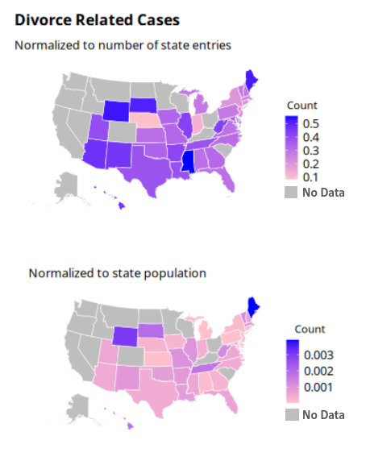

### Preparing Data for Sentiment Analysis

```r
#Run the section below once to clean the `CreatedUtc` column and change to date/time
# full_data <-
#   full_data %>%
#   mutate(
#     CreatedUtc = if_else(
#       str_detect(CreatedUtc, "^\\d{4}-\\d{2}-\\d{2} \\d{2}:\\d{2}:\\d{2}$"),
#       CreatedUtc,
#       NA_character_
#     ),
#     CreatedUtc = ymd_hms(CreatedUtc)
#   )



client_first_posts <-
  full_data %>%
    filter((str_detect(Subcategory, "[Dd]ivorce"))) %>%
    arrange(CreatedUtc) %>%
    group_by(ClientUno) %>%
    slice(1) %>%
    arrange(CreatedUtc) %>%
    select(PostText, ClientUno, CreatedUtc, StateAbbr, AttorneyUno)
# client_first_posts

client_posts <-
  client_first_posts %>%
  ungroup() %>%
  select(PostText)
client_posts
```

```
## # A tibble: 45,908 × 1
##    PostText
##    <chr>
##  1 "hello and thank you first for participating with this service:I have a ###.…
##  2 "Hi, I am separated on the process of signing the MSA. My husband fire an at…
##  3 "Hi ###,Good question. I can assist you with this. To confirm, are you okay …
##  4 "My husband moved out of the house on ###,after stating he wanted to seperat…
##  5 "I am looking to Change my ######mo old daughters last name. She has my maid…
##  6 "IN THE CIRUIT COURTTWENTIETH JUDICIAL CIRCUITST. ### COUNTY, ILLINOIS  ### …
##  7 "Dear Ms. Long,Apparently you do not understand the legal situation or the j…
##  8 "Hi ### - To answer your first question:  No.  You need a court order.  You …
##  9 "###,    Before you send these, you should prepare either a paper document, …
## 10 "I was granted a divorce on ### and in the divorce my husband the husband wi…
## # ℹ 45,898 more rows
```

```r
#export data to csv from the first post text from any divorce related subcategory
write.csv(client_posts, './data/firstClientPosts.csv', row.names = FALSE)
```

```r
#compiling the of unresolved, unopened, and resolved divorce related posts from the ABA

posts_unresolved <-
  full_data %>%
  filter((str_detect(Subcategory, "[Dd]ivorce"))) %>%
  filter(AttorneyUno != "NULL") %>%
  select(PostText)

posts_unopened <-
  full_data %>%
  filter((str_detect(Subcategory, "[Dd]ivorce"))) %>%
  filter(AttorneyUno == "NULL") %>%
  select(PostText)

posts_resolved <-
  full_data %>%
  filter((str_detect(Subcategory, "[Dd]ivorce"))) %>%
  filter(AttorneyUno != "NULL") %>%
  select(PostText)

head(posts_unresolved,10)
```

[output not shown]

```r
head(posts_resolved,10)
```

[output not shown]

```r
head(posts_unopened,10)
```

[output not shown]

```r
#export data to csv to be processed in python
write.csv(posts_unresolved, './posts_unresolved.csv', row.names = FALSE)
write.csv(posts_resolved, './posts_resolved.csv', row.names = FALSE)
write.csv(posts_unopened, './posts_unopened.csv', row.names = FALSE)
```

### Sentiment Analysis

The compiled CSV data of the unresolved, resolved, and unopened divorce-related ABA posts were then used to conduct sentiment analysis in Python. We made two sentiment analyses: one based on the divorce-related Reddit posts and comments from r/legaladvice and the other based on the divorce-related posts and replies from the pro bono lawyers from the ABA.

All of this processing can be found in the ‘python-processing’ folder.

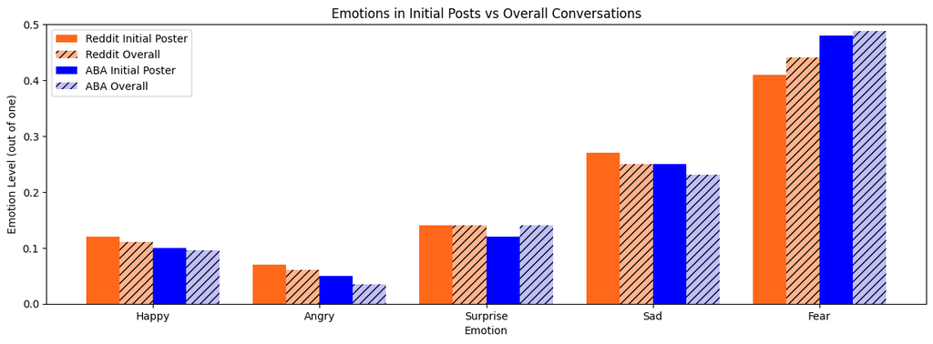

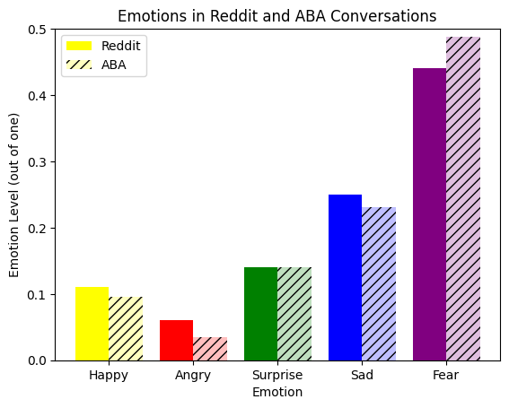

### Insights

Through looking at the data provided to us and data from Reddit, we found some interesting trends within the sentiment analysis. One trend we noticed was the language used in correspondence (for both Reddit and ABA divorce cases) had a significant amount of fear detected, more than any other emotion detected (as seen on our slides). The emotion level for fear was between 0.4 and 0.5 on a scale from zero to one. It is important to note that ABA correspondence has more fear than Reddit correspondence and when the attorney comes into play, the fear level increases. Reddit likely does not experience as high levels of fear detected in the speech because of the informality and anonymity of the platform. Also, by the time a client reaches the step of reaching out to a lawyer, their fear level has had time to increase. Knowing this, ABA attorneys should adjust the language they use to be more approachable which would put the client at ease. We would expect this to decrease the fear level and increase the happiness level of ABA correspondence.

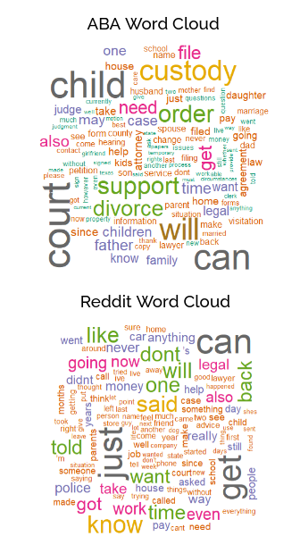